# Supporting items for NTA Conference Paper

### Supplementary Item 13 Additional FEMA descriptive and distributional checks

Historical cohort plots are paired with current conditional-trend, transformation and distributional-source documentation. Historical and current model samples must be checked before substitution.

Source plot: q2_assumption_graphs_files/figure-html/fig-figure6-1.png

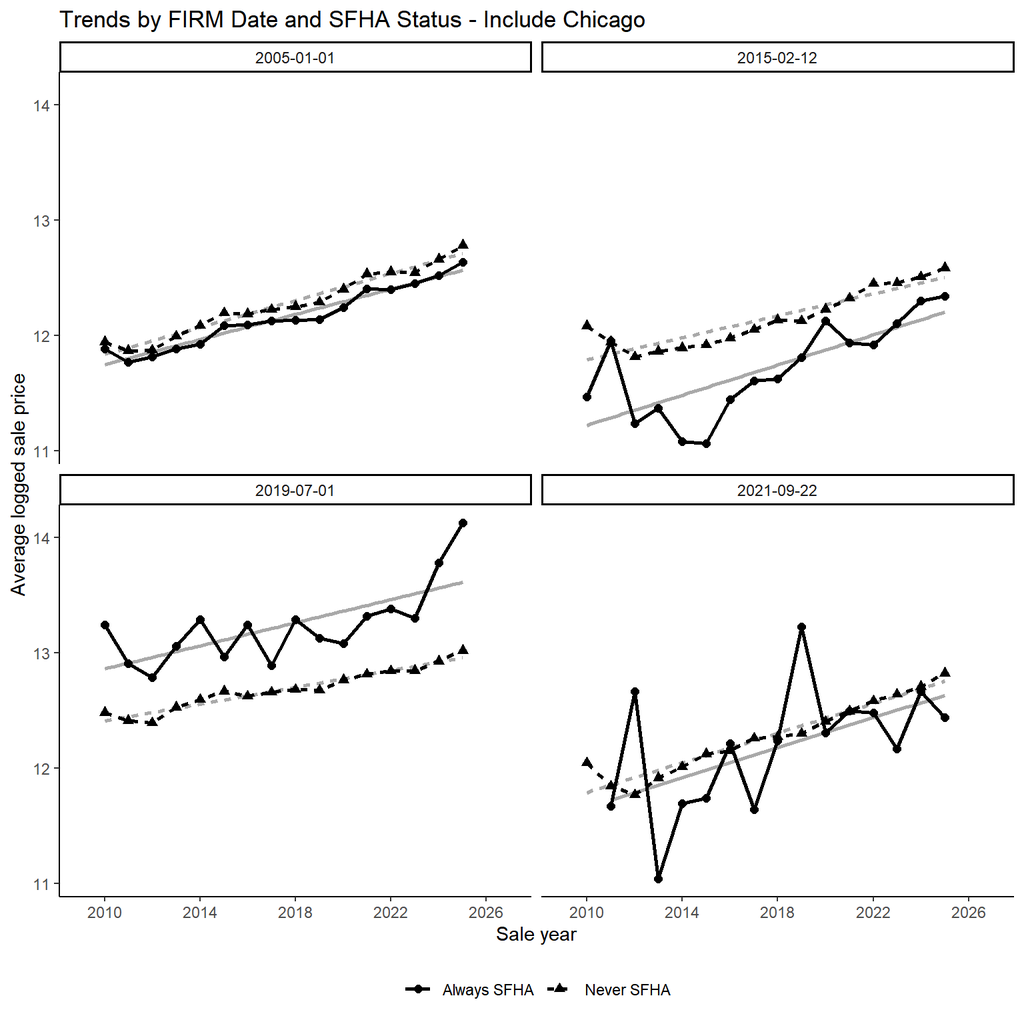

Source plot: q2_assumption_graphs_files/figure-html/fig-figure7-1.png

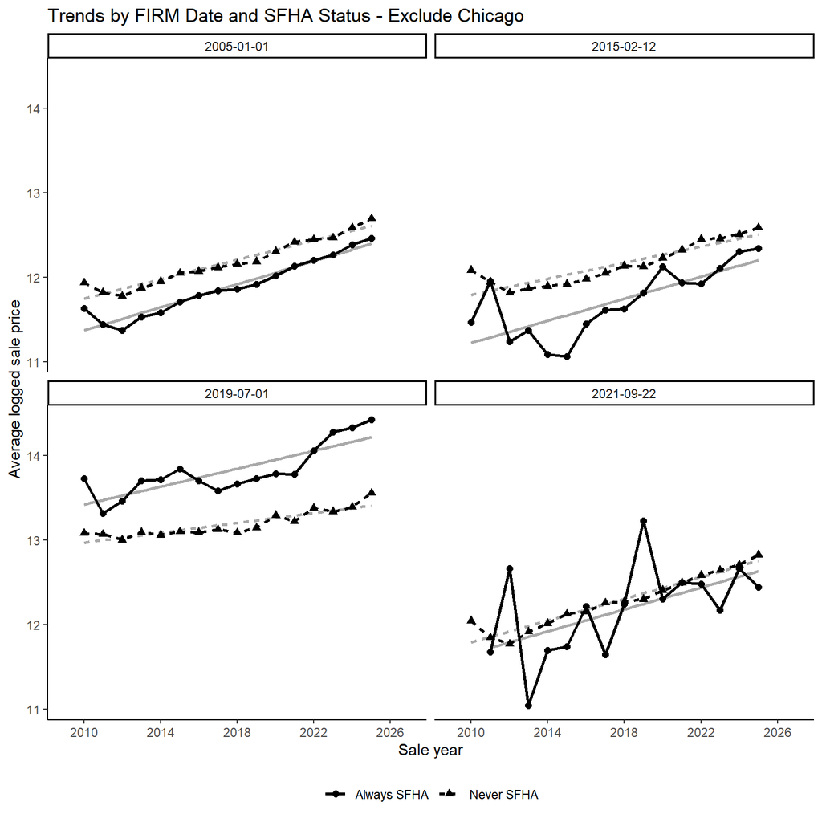

Source plot: q2_assumption_graphs_files/figure-html/unnamed-chunk-2-1.png

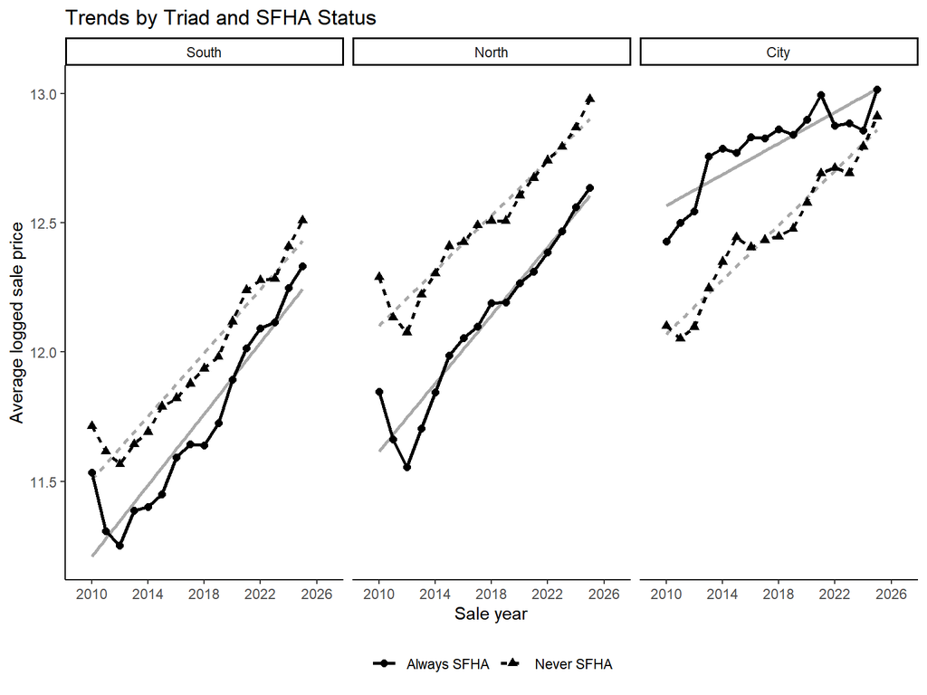

Source plot: q2_assumption_graphs_files/figure-html/fig-rq1-appendix-fig13-1.png

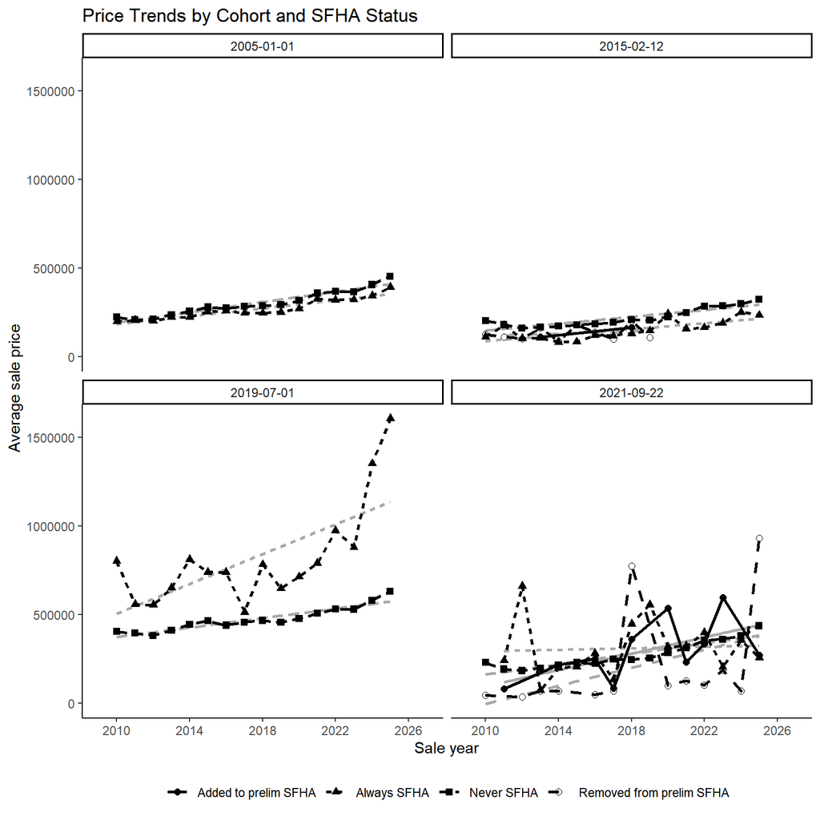

Source plot: q2_assumption_graphs_files/figure-html/fig-rq1-figure14-1.png

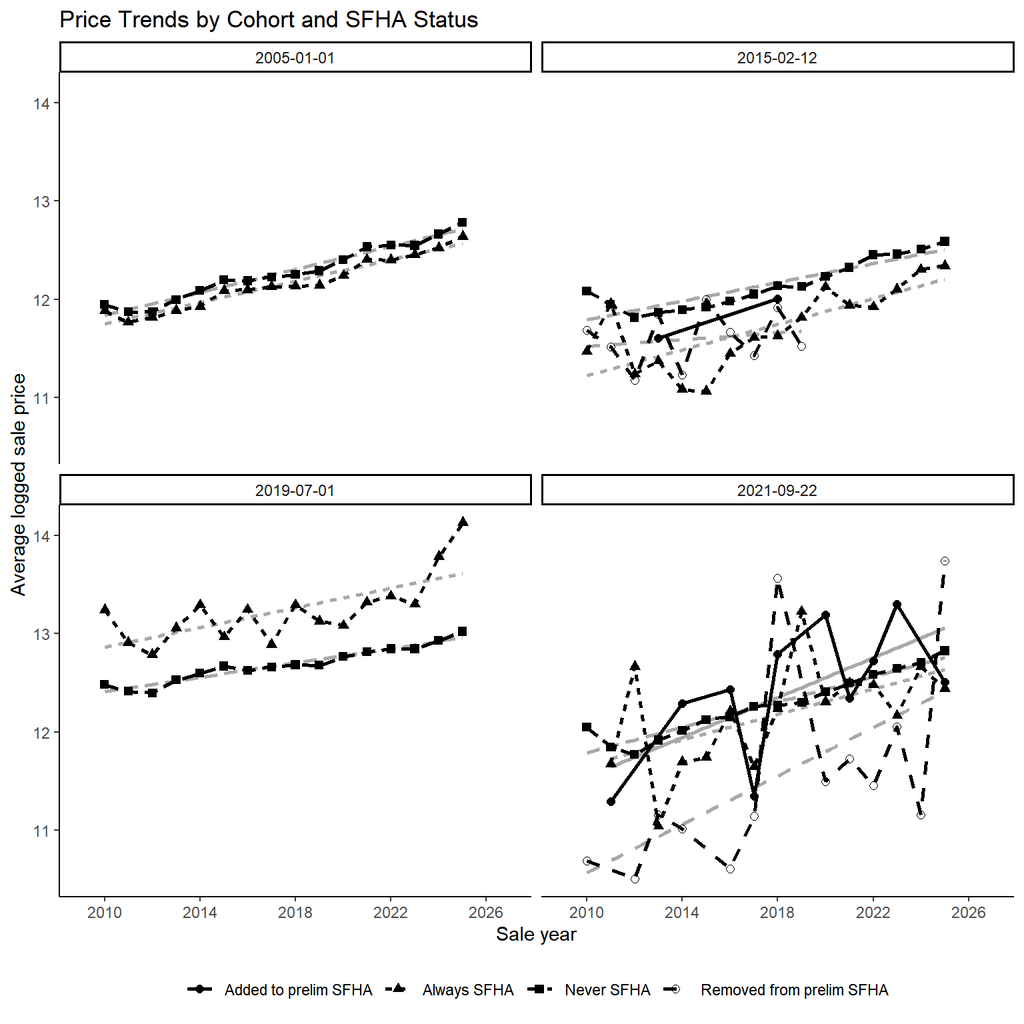

Source: `docs/q1-text-material.html#q1-conditional-trends`.

## Regional controls and conditional parallel trends

Appendix A considers whether regional housing-market differences affect the Q1 comparisons. The specifications below adapt the existing triad-by-year event studies in `q1_assumption_tests.qmd` to the same addition and removal samples used above. They replace common year effects with `sale_year^Triad` while retaining property fixed effects and parcel-clustered standard errors. These are region-by-year fixed effects, not separate linear trend slopes.

The comparisons use a common complete-case sample for each treatment direction, so differences between the two specifications are not caused by missing triad identifiers. The joint tests concern the included pretreatment coefficients relative to year -1; failure to reject does not establish the unobserved post-treatment counterfactual. These tables are newly assembled from the existing specifications, not a verified reproduction of a numbered dissertation table.

```
 Added to/from preliminary SFHA: coefficient comparison
                                 Common year effects Triad-by-year eff..
Dependent Var.:                      log(sale_price)     log(sale_price)

treated x event_time_binned = -5   0.1104** (0.0396)     0.0527 (0.0399)
treated x event_time_binned = -4 -0.5796*** (0.0064) -0.6023*** (0.0065)
treated x event_time_binned = -3 -0.2673*** (0.0038) -0.3224*** (0.0050)
treated x event_time_binned = -2 -0.0340*** (0.0048)  0.0285*** (0.0080)
treated x event_time_binned = 0   0.4876*** (0.0397)  0.5200*** (0.0405)
treated x event_time_binned = 2  -0.1036*** (0.0045) -0.1589*** (0.0057)
Fixed-Effects:                   ------------------- -------------------
pin                                              Yes                 Yes
sale_year                                        Yes                  No
sale_year-Triad                                   No                 Yes
________________________________ ___________________ ___________________
S.E.: Clustered                            by: pin10           by: pin10
Observations                                 652,380             652,380
R2                                           0.85814             0.86000
Within R2                                     4.2e-6              5.1e-6
---
Signif. codes: 0 '***' 0.001 '**' 0.01 '*' 0.05 '+' 0.1 ' ' 1

Joint pretreatment test: Added - Common year effects
Wald test, H0: joint nullity of event_time_binned::-5:treated, event_time_binned::-4:treated, event_time_binned::-3:treated and event_time_binned::-2:treated
 stat = 2,874.2, p-value < 2.2e-16, on 4 and 186,108 DoF, VCOV: Clustered (pin10).$stat
[1] 2874.188

$p
[1] 0

$df1
[1] 4

$df2
[1] 186108

$vcov
[1] "Clustered (pin10)"


Joint pretreatment test: Added - Triad-by-year effects
Wald test, H0: joint nullity of event_time_binned::-5:treated, event_time_binned::-4:treated, event_time_binned::-3:treated and event_time_binned::-2:treated
 stat = 2,996.7, p-value < 2.2e-16, on 4 and 186,108 DoF, VCOV: Clustered (pin10).$stat
[1] 2996.722

$p
[1] 0

$df1
[1] 4

$df2
[1] 186108

$vcov
[1] "Clustered (pin10)"
```

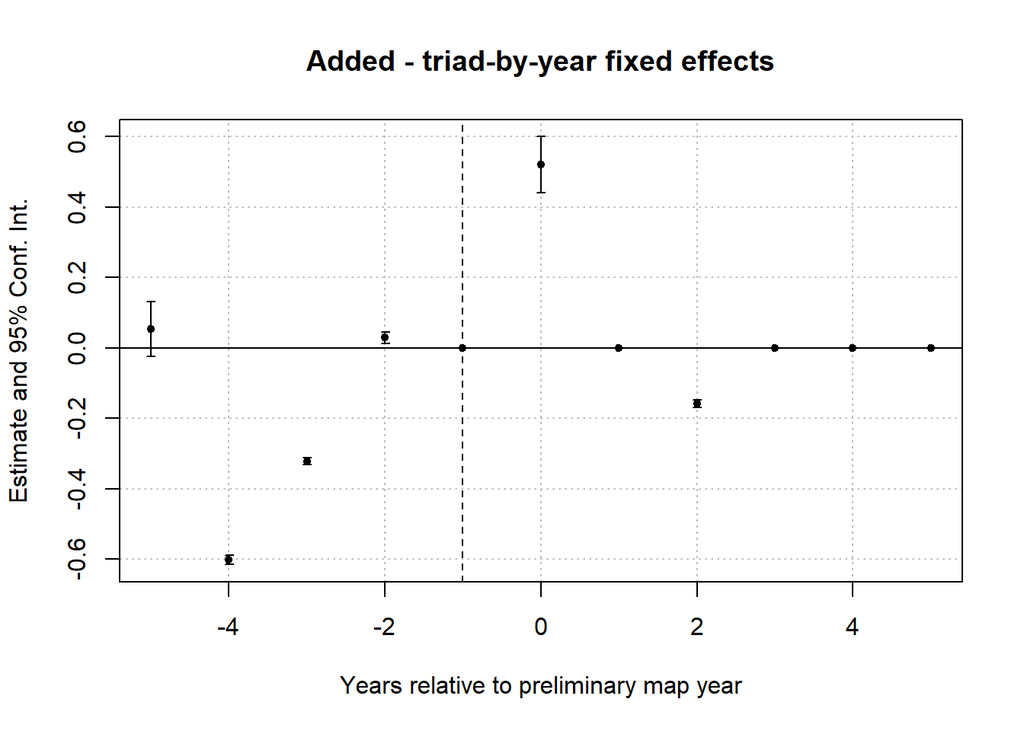

```
 Removed to/from preliminary SFHA: coefficient comparison
                                 Common year ef.. Triad-by-year e..
Dependent Var.:                   log(sale_price)   log(sale_price)

treated x event_time_binned = -5 -0.0272 (0.1430)  -0.0448 (0.1182)
treated x event_time_binned = -4  0.1548 (0.0941)   0.0705 (0.1012)
treated x event_time_binned = -3  0.0670 (0.0770)   0.0546 (0.0900)
treated x event_time_binned = -2 -0.0432 (0.1293)  -0.0507 (0.1400)
treated x event_time_binned = 0  0.2070+ (0.1074)  0.2102+ (0.1090)
treated x event_time_binned = 1  -0.0270 (0.0737)  -0.0810 (0.0673)
treated x event_time_binned = 2   0.1647 (0.1137)   0.1023 (0.1083)
treated x event_time_binned = 3  -0.2154 (0.1324) -0.2879* (0.1455)
treated x event_time_binned = 4  -0.0233 (0.1163)  -0.1154 (0.1144)
treated x event_time_binned = 5  0.1857* (0.0881)  -0.0910 (0.0890)
Fixed-Effects:                   ---------------- -----------------
pin                                           Yes               Yes
sale_year                                     Yes                No
sale_year-Triad                                No               Yes
________________________________ ________________ _________________
S.E.: Clustered                         by: pin10         by: pin10
Observations                               14,908            14,908
R2                                        0.89406           0.90859
Within R2                                 0.00109           0.00098
---
Signif. codes: 0 '***' 0.001 '**' 0.01 '*' 0.05 '+' 0.1 ' ' 1

Joint pretreatment test: Removed - Common year effects
Wald test, H0: joint nullity of event_time_binned::-5:treated, event_time_binned::-4:treated, event_time_binned::-3:treated and event_time_binned::-2:treated
 stat = 1.16631, p-value = 0.323669, on 4 and 2,609 DoF, VCOV: Clustered (pin10).$stat
[1] 1.166313

$p
[1] 0.3236692

$df1
[1] 4

$df2
[1] 2609

$vcov
[1] "Clustered (pin10)"


Joint pretreatment test: Removed - Triad-by-year effects
Wald test, H0: joint nullity of event_time_binned::-5:treated, event_time_binned::-4:treated, event_time_binned::-3:treated and event_time_binned::-2:treated
 stat = 0.437769, p-value = 0.781405, on 4 and 2,609 DoF, VCOV: Clustered (pin10).$stat
[1] 0.4377693

$p
[1] 0.7814046

$df1
[1] 4

$df2
[1] 2609

$vcov
[1] "Clustered (pin10)"
```

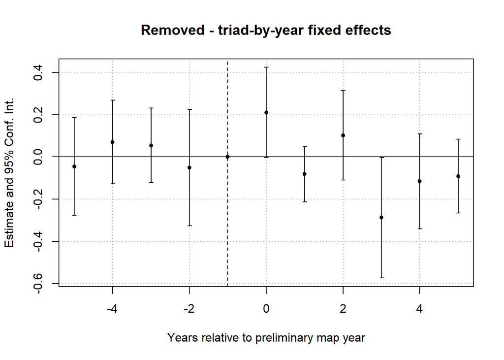

Source: `docs/q1-text-material.html#q1-outcome-transformations`.

## Outcome transformations

Appendix A (printed pages 95-97) discusses sale price in levels, logarithms, inverse price, and inverse hyperbolic sine. The plots below assemble all four transformations for the Q1 event-study samples. They use the same observations across transformations: finite, strictly positive prices in the pretreatment period, with addition and removal comparisons shown separately. The last two plots are supporting variations, not estimates of a new treatment effect.

Points are means of transformed sale prices by calendar year and treatment group, not transformations of the group mean. The panels use separate vertical scales. A year can pool observations from different preliminary-map cohorts, and the mix of sold properties can change over time; these descriptive plots therefore supplement the event studies rather than proving parallel trends. Inverse price is decreasing in price, so its direction must be interpreted accordingly. This newly assembled comparison is not an exact reconstruction of dissertation Figures 15-16.

| comparison | group | Sales | Properties |
| --- | --- | --- | --- |
| Added | Comparison group | 94653 | 60274 |
| Added | Transition group | 7 | 6 |
| Removed | Comparison group | 304 | 193 |
| Removed | Transition group | 77 | 66 |

Pretreatment observations used in each transformation

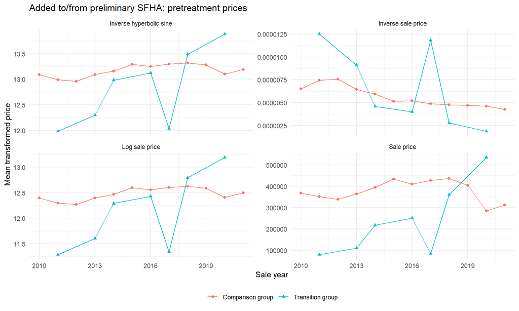

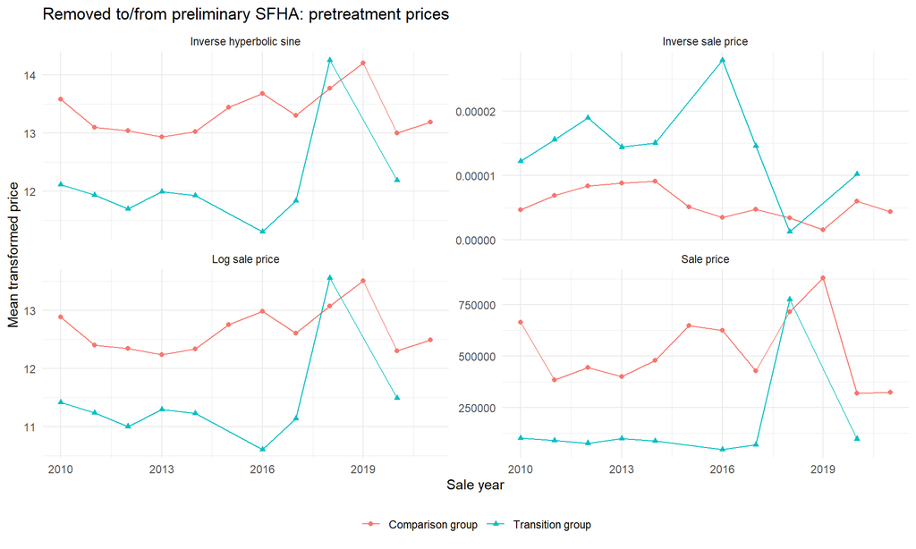

Source: `docs/q1-text-material.html#q1-distributional-tests`.

## Saved distributional parallel-trends diagnostics

Appendix A (printed pages 98-99) reports distributional diagnostics associated with Roth and Sant’Anna’s functional-form analysis. Existing results were located in `scripts/Q1_SFHA_DiD_test.R` and its saved `didFF` objects. The cells below display those saved results without re-estimating them or running the exploratory script.

The unlogged 2014/2022 object has a saved p-value of 0.99778, consistent with the rounded 0.998 in the dissertation. A second unlogged object has p-value 1. The saved logged-price object has p-value 0. These are different historical specifications; they should not be presented as uniformly supporting the same conclusion. The script overwrites the logged-price output during its later exploratory specification, so it is not a clean same-sample levels-versus-logs comparison. A large p-value is a failure to reject the diagnostic’s null, not proof of parallel trends or of the causal interpretation.

| Saved object | Code provenance and interpretation |
| --- | --- |
| `didFF_Q1_model_notlogged.rds` | Uses the older parcel dataset `df_prep_land_updated_final.rds`, retains 2014 and 2022 sales, averages within property-year, and assigns the transition group to 2022. Outcome: sale price. |
| `didFF_Q1_model_out.rds` | Last written by the later logged-price specification, which assigns group 2021 using transition status and sale date relative to the preliminary date. This assignment can vary within property. |
| `didFF_model_Q1_out2.rds` | Later unlogged-price specification with the same sale-date-dependent group construction. It is distinct from the 2014/2022 comparison. |

The latter two grouping constructions require methodological review before being used as confirmatory evidence. The saved objects do not establish that these samples match the current building-based Q1 models. The historical output is shown here to make the dissertation’s diagnostic evidence traceable, including the result that differs from its summary.

```
Sale price: 2014/2022 specification
Saved p-value: 0.99778
NULL

Logged price: later exploratory specification
Saved p-value: 0
NULL

Sale price: later exploratory specification
Saved p-value: 1
NULL
```